# Introduction to Text Mining

Ahmad Husain Abdullah

November 21, 2019

# Overview

The topic to be discussed is about *introduction to text mining*. We will go through brief explanation about step to process text data including data preparation, exploratory data analysis, and modeling. I recommend that you have:

- Familiarity with R programming
- Familiarity with data analysis workflow
  - data preparation
  - cross validation
  - model fitting
  - model evaluation
- a high curiosity and willingness to learn in term of text data processing.

# Concept Maps

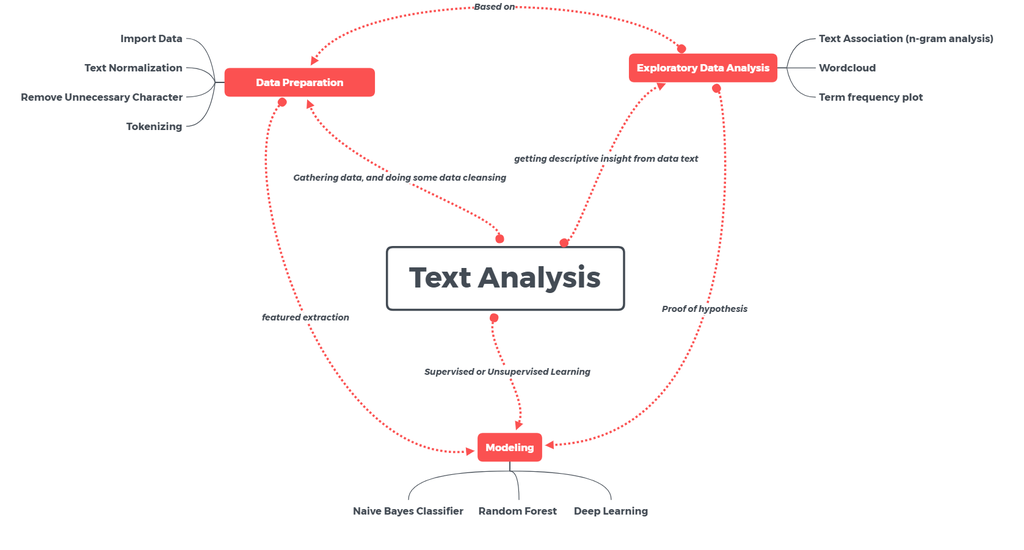

# Use Case: Twitter US Airline Sentiment

## The Main Problem

Analyze how travelers in February 2015 expressed their feelings on twitter.

*Dataset*:

| text | airline_sentiment |
| --- | --- |
| @VirginAmerica What @dhepburn said. | neutral |
| @VirginAmerica plus you’ve added commercials to the experience… tacky. | positive |
| @VirginAmerica I didn’t today… Must mean I need to take another trip! | neutral |
| @VirginAmerica it’s really aggressive to blast obnoxious “entertainment” in your guests’ faces &amp; they have little recourse | negative |
| @VirginAmerica and it’s a really big bad thing about it | negative |
| @VirginAmerica seriously would pay $30 a flight for seats that didn’t have this playing. it’s really the only bad thing about flying VA | negative |

# Steps of analysis

- Data Preparation
- Exploratory Data Ananlysis
- Modeling

## Data Preparation

In data text problem, the common ways to prepare the data includes:

1. Text Normalization
2. Removing Unnecessary Character
3. Tokenization & Document term matrix

The output of these processes will help build the input of the machine learning models you create to analyze your data (feature extraction).

**Text Normalization**:

1. *Replace word lengthening*.
2. *Convert all string to lowercase/uppercase*.

Example: Replace words elongations with known semantic replacements.

*@VirginAmerica heyyyy guyyyys..*, will be normalized to:

*@VirginAmarica hey guys..*

**Removing Unnecessary Character**: we will remove all characters that unexpectedly affect sentiment, such as:

- Remove number
- Remove punctuations
- Remove url
- Remove stopwords (list of common words that does not help for modeling, *e.g.: I, you, their, do, etc*)

| text_clean | airline_sentiment |
| --- | --- |
| a voucher i can not believe i took this risk not only was the plane terribly filthy and i had screaming babies in my face | negative |
| out of curiosity when a flight is arranged are pilots notified there are a lot of pilots havent arrived yet announcements | neutral |
| yes however the seats they assign us that day are never together i just want to sit with my husband why is that impossible | negative |
| lolol | positive |
| new plane easy power for laptop iphone just missing a good boatstyle swivel cup holder for my | positive |

**Tokenization**: is the act of breaking up a sequence of strings into pieces such as words, keywords, phrases, symbols and other elements called tokens.

**Document Term Matrix**:

A computer cannot store “letters”, “numbers”, “pictures” or anything else. The only thing it can store and work with are *bits* or a numerical value that represent a text.

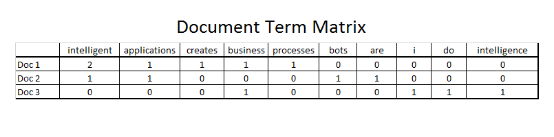

## Exploratory Data Analysis

In exploring a data text problem, one of the fundamental exploratory step is find the frequency of term from the list document text. One of the most common visualization is Wordcloud.

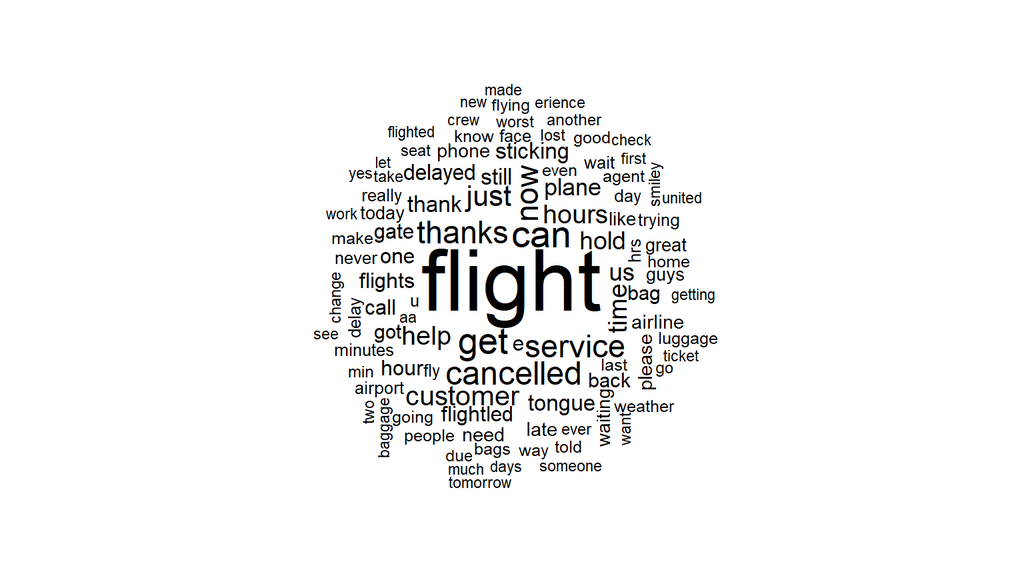

Most term frequency for each sentiment:

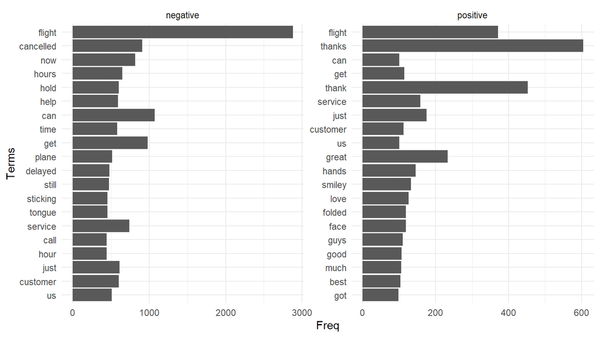

The term of *flight* more often appears as negative sentiment. So we can make an initial hypothesis, the term *flight* can increase the possibility that review will be classified as negative sentiments.

# Modeling

## Steps used Modeling

- Cross Validation

To simulate error in future or unseen dataset

- Model Fitting

Modelling process, and if needed, including prediction

- Model Evaluation

To ensure our model already have the minimal error in unseen data

Model evaluation:

| model | term | estimate |
| --- | --- | --- |
| Model1 | accuracy | 0.8945074 |
| Model1 | specificity | 0.7094017 |
| Model1 | precision | 0.9267241 |
| Model1 | recall | 0.9419496 |

An example of tweet containing the word *flight* that classified as negative sentiment:

*@VirginAmerica I’m having trouble adding this flight my wife booked to my Elevate account. Help? http://t.co/pX8hQOKS3R*

# Quiz

## Q.1

When doing data preparation, what step that aimed for standardizing text according to their semantic meaning?

- tokenizing
- text normalization
- remove stopwords

## Q.2

These are some criteria that make up clean text data before further analysis, EXCEPT:

- numeric value does not exist in text data.
- capital format at the first letter of each word.
- there are no *word lengthening* in the text data.

## Q.3

What is the purpose of exploratory data analysis on text mining?

- to prepare raw data text into a format that is needed for model building
- process of gaining insight and improve our undestanding about text data.
- to convert text data into a numerical representative format.